# PSTAT 131 Final Project

Yanming(David) Zeng

2024-05-30

## Introduction

This section is for introducing the general public to what I’m going to do with this final project.

### My goal for the project

The goals encompass investigating and visualizing data to comprehend the correlation between price distributions and property characteristics; identifying significant determinants of home prices through characterisation; and creating regression models to forecast prices. Important details including prices, dates of sales, unique IDs, and comprehensive housing details are all included in the collection. We hope that this effort will help real estate agents, purchasers, and legislators make wise decisions by offering insightful information. A thorough grasp of the housing market is ensured by an integrated strategy that combines data exploration, feature analysis, predictive modeling.

## Preparation

### Package Loading

At first we will load the data set first and the package

```r
library(knitr)
library(tidyverse)
library(corrr)
library(ggplot2)
library(tidymodels)
library(knitr)
library(kableExtra)
library(corrplot)
library(ggcorrplot)
library(visdat)
library(vip)
```

### Loading Data Set

After that I will load my data set. This data set is taken from [Kaggle](https://www.kaggle.com/datasets/sukhmandeepsinghbrar/housing-price-dataset/data)

```r
housing_data <- read.csv("~/Desktop/Pstat131final project/Housing.csv")
knitr::kable(head(housing_data)) %>%
  kableExtra::column_spec(1:21, border_left = TRUE, border_right = TRUE) %>%
  kableExtra::kable_styling()
```

| id | date | price | bedrooms | bathrooms | sqft_living | sqft_lot | floors | waterfront | view | condition | grade | sqft_above | sqft_basement | yr_built | yr_renovated | zipcode | lat | long | sqft_living15 | sqft_lot15 |
| --- | --- | --- | --- | --- | --- | --- | --- | --- | --- | --- | --- | --- | --- | --- | --- | --- | --- | --- | --- | --- |
| 7229300521 | 20141013T000000 | 231300 | 2 | 1.00 | 1180 | 5650 | 1 | 0 | 0 | 3 | 7 | 1180 | 0 | 1955 | 0 | 98178 | 47.5112 | -122.257 | 1340 | 5650 |
| 6414100192 | 20141209T000000 | 538000 | 3 | 2.25 | 2570 | 7242 | 2 | 0 | 0 | 3 | 7 | 2170 | 400 | 1951 | 1991 | 98125 | 47.7210 | -122.319 | 1690 | 7639 |
| 5631500400 | 20150225T000000 | 180000 | 2 | 1.00 | 770 | 10000 | 1 | 0 | 0 | 3 | 6 | 770 | 0 | 1933 | 0 | 98028 | 47.7379 | -122.233 | 2720 | 8062 |
| 2487200875 | 20141209T000000 | 604000 | 4 | 3.00 | 1960 | 5000 | 1 | 0 | 0 | 5 | 7 | 1050 | 910 | 1965 | 0 | 98136 | 47.5208 | -122.393 | 1360 | 5000 |
| 1954400510 | 20150218T000000 | 510000 | 3 | 2.00 | 1680 | 8080 | 1 | 0 | 0 | 3 | 8 | 1680 | 0 | 1987 | 0 | 98074 | 47.6168 | -122.045 | 1800 | 7503 |
| 7237550310 | 20140512T000000 | 1225000 | 4 | 4.50 | 5420 | 101930 | 1 | 0 | 0 | 3 | 11 | 3890 | 1530 | 2001 | 0 | 98053 | 47.6561 | -122.005 | 4760 | 101930 |

This data set is including different factors that possible affect the price. Here are the introduction for these data:

-**id**: Unique identifier for each property

-**data**: Date of property listing

-**price**: Property price in currency

-**bedrooms**: Number of bedrooms

-**bathrooms**: Number of bathrooms

-**sqft_living**: Living area size in square feet

-**sqft_lot**: Total lot size in square feet

-**floors**: Number of floors

-**waterfront**:Indicates if property has waterfront view (0 for no, 1 for yes)

-**view**: Quality level of property view (0 to 4)

-**condition**: Overall condition rating (1 to 5)

-**grade**: Overall grade rating (1 to 13)

-**sqft_above**: Living area above ground level in square feet

-**sqft_basement**:Basement area in square feet

-**yr_built**: Year property was built

-**yr_renovated**: Year property was last renovated (0 if never)

-**zipcode**: Property location zip code

-**lat**:Latitude coordinate of property location

-**long**: Longitude coordinate of property location

-**sqft_living15**: Living area size of 15 nearest properties in square feet

-**sqft_lot15**: Lot size of 15 nearest properties in square feet

## Exploratory Data Analysis

### Variable Selection

```r
dim(housing_data)
```

```
## [1] 21613    21
```

There is 21613 observations and 21 variables. Deducting the response variable, there is still 20 variables left as our predictors!

However, There is some variables that I think we don’t need the consider. At first is the **id** in my model, because I don’t think my models need special markings. The modeling I do is designed to help the market better understand price trend factors.

Second, Because my model is more about examining the influences on market price trends, for the vast majority of consumers, longitude（**long**) and latitude(**lat**) are not relevant as a factor influencing them to buy a house. So I think I’m justified in removing these two factors

Third, the zipcode is too dummy as a factor, so I also need to remove this one as well.

```r
housing_data<-housing_data%>%
  select(-id,-long,-lat, -zipcode)
```

Next we will tidy these large data set

### Tidying data

```r
unique_values_count <- sapply(housing_data, function(x) length(unique(x)))
kable(unique_values_count)%>%
  kableExtra::column_spec(1:2, border_left = TRUE, border_right = TRUE) %>%
  kableExtra::kable_styling()
```

|  | x |
| --- | --- |
| date | 372 |
| price | 4029 |
| bedrooms | 13 |
| bathrooms | 30 |
| sqft_living | 1038 |
| sqft_lot | 9782 |
| floors | 6 |
| waterfront | 2 |
| view | 5 |
| condition | 5 |
| grade | 12 |
| sqft_above | 946 |
| sqft_basement | 306 |
| yr_built | 116 |
| yr_renovated | 70 |
| sqft_living15 | 777 |
| sqft_lot15 | 8689 |

From the chart above, we can know that these data are all we need for our next step. In the index of the year of renovation(**yr_renovated**), we don’t need to know exactly what year it was renovated. We can convert it to whether it was renovated and use it as a factor. This way we can better model this prediction. Also, we can convert the built of the year to a new value called Age. This variable is made up of 2024 - the year it was built. This new variable is more useful to help us organize the dataset because we don’t need to calculate how many years the house was built.

```r
housing_data <- housing_data %>%
  mutate(
    Age = 2024 - yr_built,
    Renovated = if_else(yr_renovated > 0, 1, 0))%>%
  select(-yr_renovated,-yr_built)

head(housing_data)
```

```
##              date   price bedrooms bathrooms sqft_living sqft_lot floors
## 1 20141013T000000  231300        2      1.00        1180     5650      1
## 2 20141209T000000  538000        3      2.25        2570     7242      2
## 3 20150225T000000  180000        2      1.00         770    10000      1
## 4 20141209T000000  604000        4      3.00        1960     5000      1
## 5 20150218T000000  510000        3      2.00        1680     8080      1
## 6 20140512T000000 1225000        4      4.50        5420   101930      1
##   waterfront view condition grade sqft_above sqft_basement sqft_living15
## 1          0    0         3     7       1180             0          1340
## 2          0    0         3     7       2170           400          1690
## 3          0    0         3     6        770             0          2720
## 4          0    0         5     7       1050           910          1360
## 5          0    0         3     8       1680             0          1800
## 6          0    0         3    11       3890          1530          4760
##   sqft_lot15 Age Renovated
## 1       5650  69         0
## 2       7639  73         1
## 3       8062  91         0
## 4       5000  59         0
## 5       7503  37         0
## 6     101930  23         0
```

The next important factor we need to consider is the date, because the date of release for sale is not an important factor in the price trend. so we omit this variable.

```r
housing_data<-housing_data%>%
  select(-date)
head(housing_data)
```

```
##     price bedrooms bathrooms sqft_living sqft_lot floors waterfront view
## 1  231300        2      1.00        1180     5650      1          0    0
## 2  538000        3      2.25        2570     7242      2          0    0
## 3  180000        2      1.00         770    10000      1          0    0
## 4  604000        4      3.00        1960     5000      1          0    0
## 5  510000        3      2.00        1680     8080      1          0    0
## 6 1225000        4      4.50        5420   101930      1          0    0
##   condition grade sqft_above sqft_basement sqft_living15 sqft_lot15 Age
## 1         3     7       1180             0          1340       5650  69
## 2         3     7       2170           400          1690       7639  73
## 3         3     6        770             0          2720       8062  91
## 4         5     7       1050           910          1360       5000  59
## 5         3     8       1680             0          1800       7503  37
## 6         3    11       3890          1530          4760     101930  23
##   Renovated
## 1         0
## 2         1
## 3         0
## 4         0
## 5         0
## 6         0
```

```r
write.csv(housing_data,"housing_data.csv")
```

Now, the data looks perfect and we can continue to our next step.

### Convert data type

At first, we need to know each type of data clearly

```r
housing<-read.csv("~/Desktop/Pstat131final project/housing_data.csv")%>%
  select(-X)
variable <- sapply(housing, class)
variable%>%
  kable()%>%
  kableExtra::column_spec(1:2, border_left = TRUE, border_right = TRUE) %>%
  kableExtra::kable_styling()
```

|  | x |
| --- | --- |
| price | numeric |
| bedrooms | integer |
| bathrooms | numeric |
| sqft_living | integer |
| sqft_lot | integer |
| floors | numeric |
| waterfront | integer |
| view | integer |
| condition | integer |
| grade | integer |
| sqft_above | integer |
| sqft_basement | integer |
| sqft_living15 | integer |
| sqft_lot15 | integer |
| Age | integer |
| Renovated | integer |

Now, we need to convert some data in to factor

```r
housing$floors<-as.factor(housing$waterfront)
housing$waterfront<-as.factor(housing$waterfront)
housing$view<-as.factor(housing$view)
housing$condition<-as.factor(housing$condition)
housing$grade<-as.factor(housing$grade)
housing$Renovated<-as.factor(housing$Renovated)
```

Now We can see our new data set

```r
variable <- sapply(housing, class)
variable%>%
  kable()%>%
  kableExtra::column_spec(1:2, border_left = TRUE, border_right = TRUE) %>%
  kableExtra::kable_styling()
```

|  | x |
| --- | --- |
| price | numeric |
| bedrooms | integer |
| bathrooms | numeric |
| sqft_living | integer |
| sqft_lot | integer |
| floors | factor |
| waterfront | factor |
| view | factor |
| condition | factor |
| grade | factor |
| sqft_above | integer |
| sqft_basement | integer |
| sqft_living15 | integer |
| sqft_lot15 | integer |
| Age | integer |
| Renovated | factor |

### Check Miss Data

In this part, I will check if there any missing data in this data set.

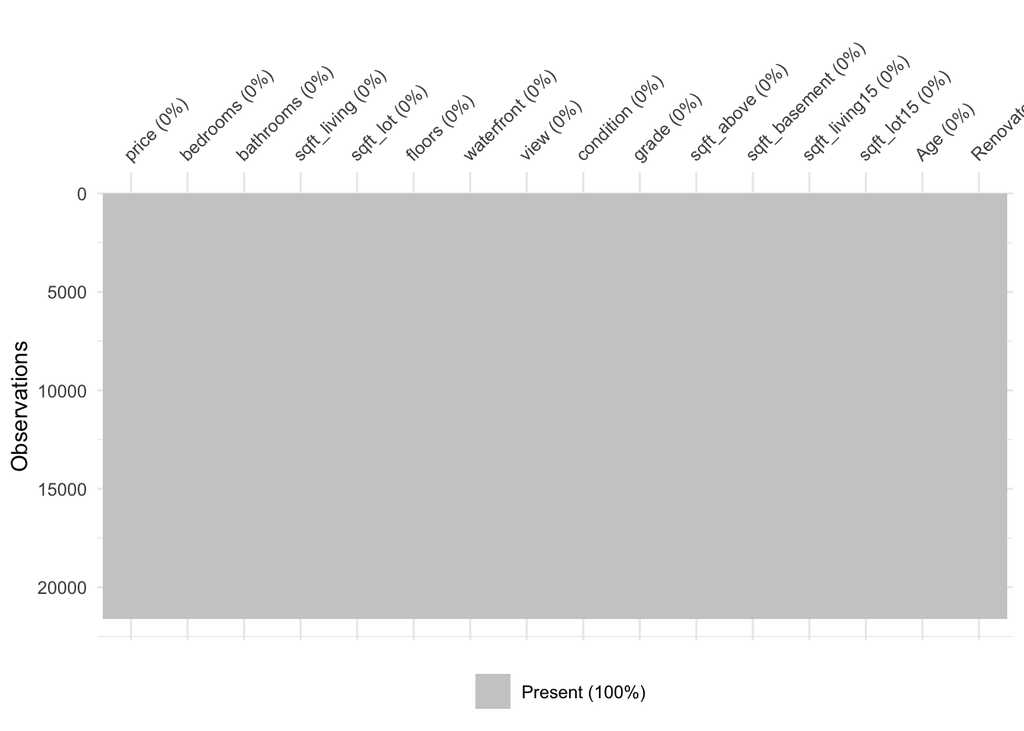

```r
vis_miss(housing)
```

Obviously show that there is no missing housing data in it.

### Data Visualization

#### Distribution of Price

If we want to make the reserach on price, we need to know the price’s distribution

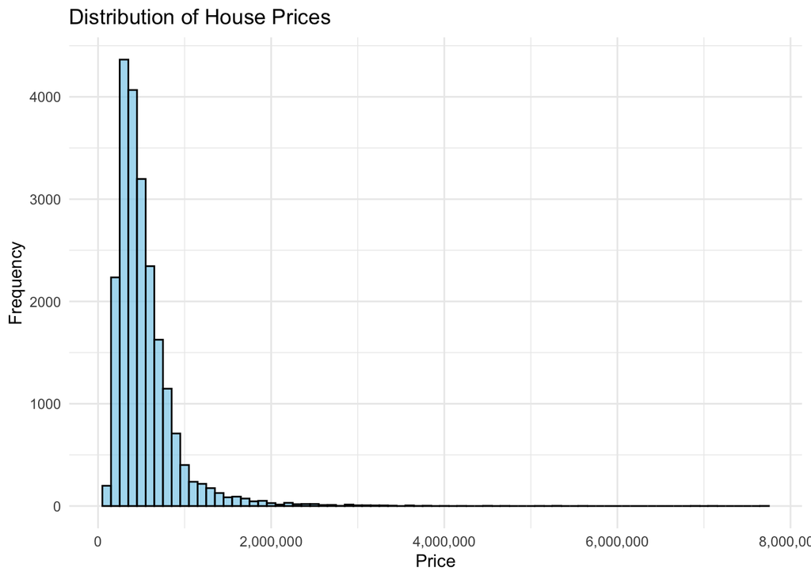

```r
ggplot(housing, aes(x = price)) +
  geom_histogram(binwidth = 100000, fill = "skyblue", color = "black", alpha = 0.7) +
  labs(title = "Distribution of House Prices", x = "Price", y = "Frequency") +
  theme_minimal() +
  scale_x_continuous(labels = scales::comma)
```

#### Correlation Heatmap of price and factors

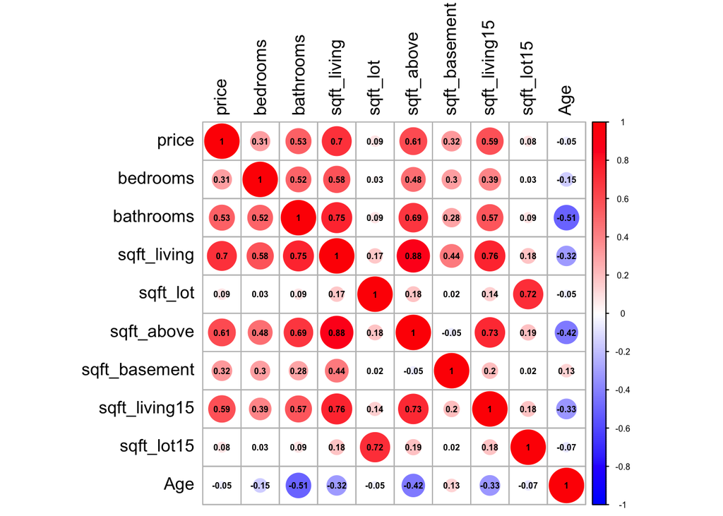

```r
housing_numeric <- housing %>%
  select_if(is.numeric)
housing_numeric <- housing_numeric[, !names(housing_numeric) %in% c("column1_with_NA", "column2_with_NA")]
housing_cor <- cor(housing_numeric, use = "complete.obs")
corrplot(housing_cor, method = "circle", addCoef.col = "black", number.cex = 0.5,
         tl.cex =1, tl.col = "black", cl.cex = 0.5, col = colorRampPalette(c("blue", "white", "red"))(200))
```

```r
price_correlations <- housing_cor[, "price"]
sorted_price_correlations <- sort(abs(price_correlations), decreasing = TRUE)
print(sorted_price_correlations)
```

```
##         price   sqft_living    sqft_above sqft_living15     bathrooms
##    1.00000000    0.70203460    0.60556704    0.58537838    0.52513632
## sqft_basement      bedrooms      sqft_lot    sqft_lot15           Age
##    0.32381557    0.30837692    0.08966068    0.08244693    0.05401094
```

#### Relationship between the Square living and Price

As we know the Square living has the biggest influence to the price. We can explore their relationship further for advance.

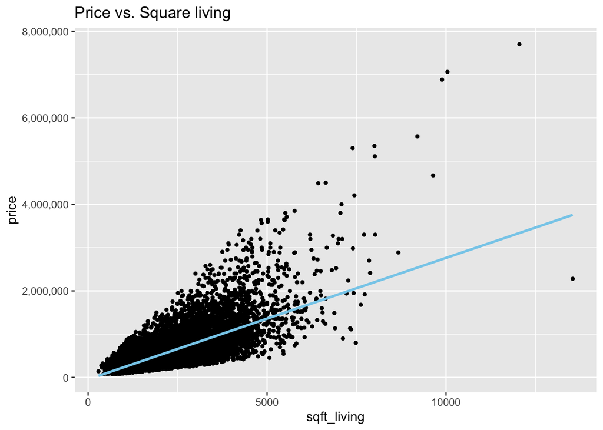

```r
housing %>%
  ggplot(aes(x=sqft_living, y=price)) +
  geom_jitter(width = 0.5, size = 1) +
  geom_smooth(method = "lm", se =F, col="skyblue") +
  labs(title = "Price vs. Square living")+
  scale_y_continuous(labels = scales::comma)
```

This graphic clearly shows a strong positive link between living square footage and pricing. The larger the value of residential square footage (more than 4,000 square feet), the bigger the price variance. This implies that, while larger homes are normally more expensive, the price gap is greater in larger homes, which might be due to other factors such as location, amenities, or overall quality.

## Set up a model

I will set up the models for my next step in this part. I picked the Root Mean Square Error (RMSE) as a metric since it can be used to assess the overall performance of all models.RMSE is a popular statistic for evaluating regression model performance.

### Split the data set

At first we need to split the data set into training and testing. After that we need to create the 5-fold cross-validation to the training set.

```r
set.seed(2620)
housing_split <- initial_split(housing, prop = 0.7, strata = price)
housing_train <- training(housing_split)
housing_test <- testing(housing_split)
housing_folds <- vfold_cv(housing_train,v=5,strata = price)
```

However, we need to check if we used 70% of data for training

```r
nrow(housing_train)/nrow(housing)
```

```
## [1] 0.6999028
```

It seems it is very close to 70%. So I think is good.

### Create Recipes

A recipe is required for future models since a single recipe may be utilized in several models without the need to create new ones.

```r
housing_recipe <- recipe(price~., data = housing_train)%>%
  step_dummy(all_nominal_predictors(), -all_outcomes())%>%
  step_nzv(all_predictors())%>%
  step_center(all_predictors(), -all_outcomes()) %>%
  step_scale(all_predictors(), -all_outcomes())
```

## Model Building

This section covers formal model creation, which includes KNN, linear regression, elastic net linear regression, and random forest.

```r
lmmodel <- linear_reg() %>%
  set_engine("lm")


knnmodel <- nearest_neighbor(neighbors = tune()) %>%
  set_mode("regression") %>%
  set_engine("kknn")

elasticsp <- linear_reg(penalty = tune(),
                           mixture = tune()) %>%
  set_mode("regression") %>%
  set_engine("glmnet")

rfsp <- rand_forest(mtry = tune(),
                       trees = tune(),
                       min_n = tune()) %>%
  set_engine("ranger", importance = "impurity") %>%
  set_mode("regression")
```

### Create Work Flow

```r
lm_wokflow <- workflow() %>%
  add_model(lmmodel) %>%
  add_recipe(housing_recipe)

knn_wokflow <- workflow() %>%
  add_model(knnmodel) %>%
  add_recipe(housing_recipe)

elastic_wokflow <- workflow() %>%
  add_recipe(housing_recipe) %>%
  add_model(elasticsp)

rf_wokflow <- workflow() %>%
  add_recipe(housing_recipe) %>%
  add_model(rfsp)
```

Next step, we need to tune our parameters

### Tune Parameters

```r
kngrid1 <- grid_regular(neighbors(range = c(1,15)), levels = 5)

elasticgri1 <- grid_regular(penalty(range = c(-5, 5)), mixture(range = c(0,1)), levels = 10)

rf_grid <- grid_regular(mtry(range = c(1, 12)), trees(range = c(200,1000)), min_n(range = c(5,20)), levels = 5)
```

Then, tweak the model and provide the procedure, including k-fold cross validation folds.

```r
knntune1 <- tune_grid(
    knn_wokflow,
    resamples = housing_folds,
    grid = kngrid1
)

elastictune1 <- tune_grid(
  elastic_wokflow,
  resamples = housing_folds,
  grid = elasticgri1
)

rftune1 <- tune_grid(
  rf_wokflow,
  resamples = housing_folds,
  grid = rf_grid
)
```

Finally, we can save our results for convenience.

```r
write_rds(knntune1, file = "knn.rds")

write_rds(elastictune1, file = "elastic.rds")

write_rds(rftune1, file = "randomforests.rds")
```

### Autoplot of the model

At first, we need to load our models first.

#### KNN Model

```r
knn<-read_rds(file = "knn.rds")
knntune1 <- knn
elastic <- read_rds(file = "elastic.rds")
elastictune1 <- elastic
randomforest <- read_rds(file = "randomforests.rds")
rftune1 <- randomforest
```

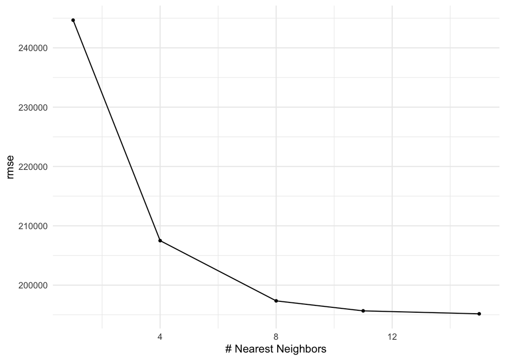

```r
autoplot(knn,metric = 'rmse')+theme_minimal()
```

This figure shows the relationship between different numbers of Nearest Neighbors and RMSE (Root Mean Square Error).This graphic clearly shows that as the number of nearest neighbors rises, the RMSE value steadily falls. This suggests that increasing the number of nearest neighbors increases the model’s prediction performance while decreasing prediction error. When the number of nearest neighbors reaches four, the fall in RMSE slows dramatically. This means that once there are a given number of nearest neighbors, adding more nearest neighbors has a limited effect on model performance improvement. The graphic shows that the drop in RMSE tends to level off when the number of nearest neighbors ranges between 8 and 12. As a result, the number of nearest neighbors in this interval is a preferable option since they provide limited performance advantage and increasing computational cost as the number of nearest neighbors increases.

#### Elastic Net Model

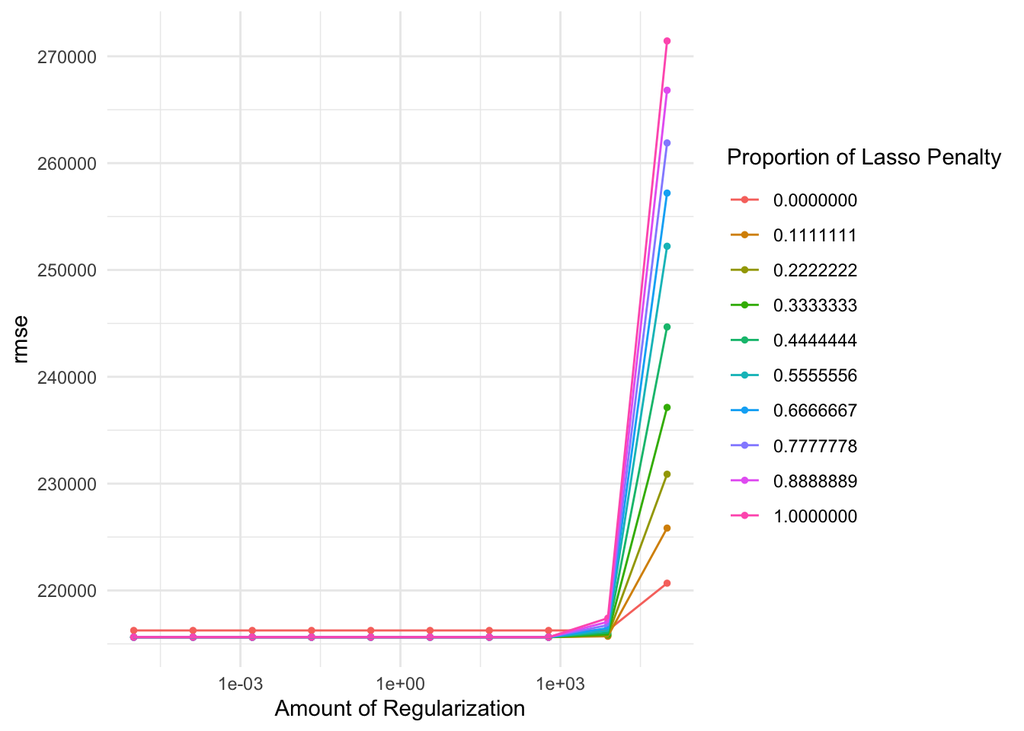

```r
autoplot(elastic, metric = 'rmse')+theme_minimal()
```

This figure depicts the tuning performance of the elastic net model, exhibiting the influence of increasing degrees of regularization on the model’s accuracy as assessed by the RMSE. In the lower range of regularization strengths (roughly less than 1e+03), the RMSE is stable and produces reasonably low and consistent errors for all Lasso penalty ratios. This shows that the model can fit the data better with lower regularization strengths. When the regularization intensity crosses a specific threshold (about 1e+03), the RMSE increases considerably. This shows that over-regularization results in an oversimplified model that misses crucial elements in the data, resulting in increased prediction errors. Different Lasso penalty proportions have no influence on the RMSE at low regularization intensities; however, at high regularization intensities, greater Lasso penalty proportions (around 1.0) result in higher RMSEs.This shows that Lasso penalties have a bigger simplifying effect on the model at higher regularization intensities, perhaps leading to model underfitting.

##### Random Forest Model

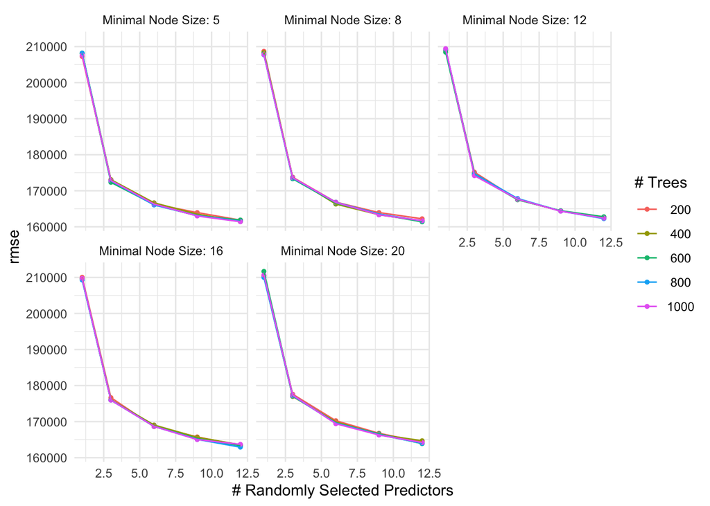

```r
autoplot(randomforest, metric = 'rmse')+theme_minimal()
```

Next, we will try to figure it out which is the best performance model

First we need to look at different models’ RMSE

#### RMSE

```r
lm_fit <- fit_resamples(lm_wokflow, resamples = housing_folds)
collect_metrics(lm_fit)%>%
  filter(.metric=="rmse")%>%
  kable()%>%
  column_spec (1:6,border_left = T, border_right = T) %>%
  kable_styling()
```

| .metric | .estimator | mean | n | std_err | .config |
| --- | --- | --- | --- | --- | --- |
| rmse | standard | 231295.2 | 5 | 4491.672 | Preprocessor1_Model1 |

```r
collect_metrics(knntune1)%>%
  filter(.metric=="rmse")%>%
  arrange(mean)%>%
  kable()%>%
  column_spec (1:7,border_left = T, border_right = T) %>%
  kable_styling()
```

| neighbors | .metric | .estimator | mean | n | std_err | .config |
| --- | --- | --- | --- | --- | --- | --- |
| 15 | rmse | standard | 195161.2 | 5 | 3823.190 | Preprocessor1_Model5 |
| 11 | rmse | standard | 195661.6 | 5 | 3703.332 | Preprocessor1_Model4 |
| 8 | rmse | standard | 197347.8 | 5 | 3558.548 | Preprocessor1_Model3 |
| 4 | rmse | standard | 207499.2 | 5 | 3398.363 | Preprocessor1_Model2 |
| 1 | rmse | standard | 244667.0 | 5 | 4174.094 | Preprocessor1_Model1 |

```r
collect_metrics(elastictune1)%>%
  filter(.metric=="rmse")%>%
  arrange(mean)%>%
  head(5)%>%
  kable()%>%
  column_spec (1:7,border_left = T, border_right = T) %>%
  kable_styling()
```

| penalty | mixture | .metric | .estimator | mean | n | std_err | .config |
| --- | --- | --- | --- | --- | --- | --- | --- |
| 0.0000100 | 0.6666667 | rmse | standard | 215620.6 | 5 | 3555.355 | Preprocessor1_Model061 |
| 0.0001292 | 0.6666667 | rmse | standard | 215620.6 | 5 | 3555.355 | Preprocessor1_Model062 |
| 0.0016681 | 0.6666667 | rmse | standard | 215620.6 | 5 | 3555.355 | Preprocessor1_Model063 |
| 0.0215443 | 0.6666667 | rmse | standard | 215620.6 | 5 | 3555.355 | Preprocessor1_Model064 |
| 0.2782559 | 0.6666667 | rmse | standard | 215620.6 | 5 | 3555.355 | Preprocessor1_Model065 |

```r
collect_metrics(rftune1)%>%
  filter(.metric=="rmse")%>%
  arrange(mean)%>%
  head(5)%>%
  kable()%>%
  column_spec (1:9,border_left = T, border_right = T) %>%
  kable_styling()
```

| mtry | trees | min_n | .metric | .estimator | mean | n | std_err | .config |
| --- | --- | --- | --- | --- | --- | --- | --- | --- |
| 12 | 600 | 8 | rmse | standard | 161387.7 | 5 | 2766.378 | Preprocessor1_Model040 |
| 12 | 1000 | 5 | rmse | standard | 161415.4 | 5 | 2855.306 | Preprocessor1_Model025 |
| 12 | 400 | 5 | rmse | standard | 161455.5 | 5 | 3006.822 | Preprocessor1_Model010 |
| 12 | 800 | 5 | rmse | standard | 161510.6 | 5 | 2833.541 | Preprocessor1_Model020 |
| 12 | 400 | 8 | rmse | standard | 161637.0 | 5 | 2999.654 | Preprocessor1_Model035 |

After we know the RMSE for each model, we can try to select the best model right now.

#### Model Selection

```r
lm <- show_best(lm_fit,metric = 'rmse')
lm%>%
  kable()%>%
    column_spec (1:5,border_left = T, border_right = T) %>%
  kable_styling()
```

| .metric | .estimator | mean | n | std_err | .config |
| --- | --- | --- | --- | --- | --- |
| rmse | standard | 231295.2 | 5 | 4491.672 | Preprocessor1_Model1 |

```r
best_k <- select_best(knntune1,metric = 'rmse')

knnrmse <- show_best(knntune1, n = 1,metric = 'rmse')

knnrmse%>%
  kable()%>%
    column_spec (1:6,border_left = T, border_right = T) %>%
  kable_styling()
```

| neighbors | .metric | .estimator | mean | n | std_err | .config |
| --- | --- | --- | --- | --- | --- | --- |
| 15 | rmse | standard | 195161.2 | 5 | 3823.19 | Preprocessor1_Model5 |

```r
best_e <- select_best(elastictune1,metric = 'rmse')

elastic1 <- show_best(elastictune1, n = 1,metric = 'rmse')
elastic1%>%
  kable()%>%
    column_spec (1:6,border_left = T, border_right = T) %>%
  kable_styling()
```

| penalty | mixture | .metric | .estimator | mean | n | std_err | .config |
| --- | --- | --- | --- | --- | --- | --- | --- |
| 1e-05 | 0.6666667 | rmse | standard | 215620.6 | 5 | 3555.355 | Preprocessor1_Model061 |

```r
bestrandomforest <- select_best(rftune1,metric='rmse')


randomforest_rmse <- show_best(rftune1, n = 1, metric='rmse')

randomforest_rmse%>%
  kable()%>%
    column_spec (1:9,border_left = T, border_right = T) %>%
  kable_styling()
```

| mtry | trees | min_n | .metric | .estimator | mean | n | std_err | .config |
| --- | --- | --- | --- | --- | --- | --- | --- | --- |
| 12 | 600 | 8 | rmse | standard | 161387.7 | 5 | 2766.378 | Preprocessor1_Model040 |

Next step, we can make a graph to figure it out which is the best perfomance model.

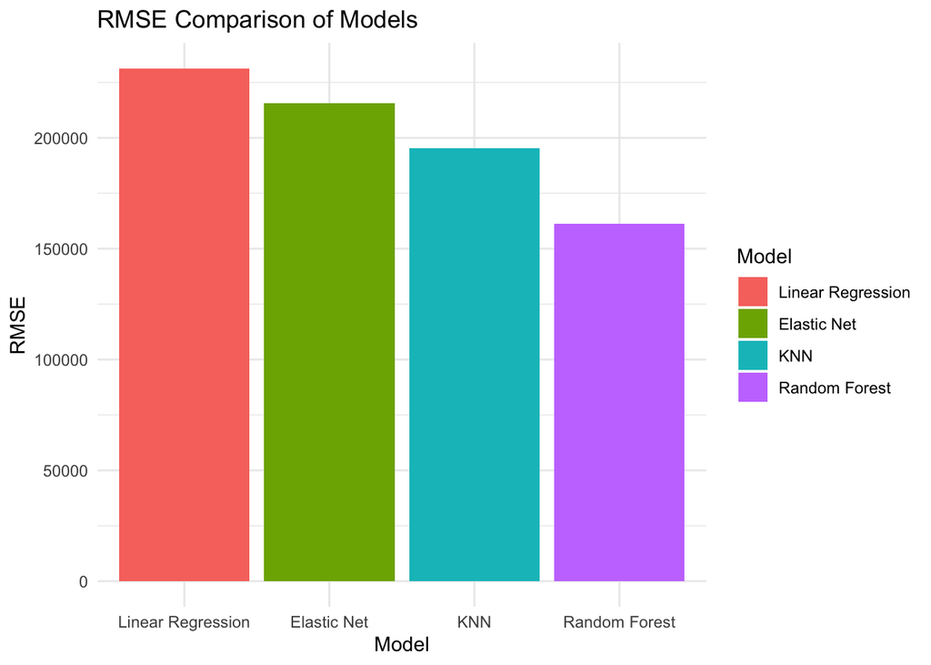

```r
rmse_data <- data.frame(
  Model = c("Linear Regression","Random Forest", "Elastic Net", "KNN"),
  RMSE = c(lm$mean,randomforest_rmse$mean, elastic1$mean, knnrmse$mean)
)
rmse_data <- rmse_data %>%
  arrange(desc(RMSE)) %>%
  mutate(Model = factor(Model, levels = Model))

ggplot(rmse_data, aes(x = Model, y = RMSE, fill = Model)) +
  geom_bar(stat = "identity") + labs(title = "RMSE Comparison of Models",
       x = "Model",
       y = "RMSE") + theme_minimal()
```

### Model Fitting

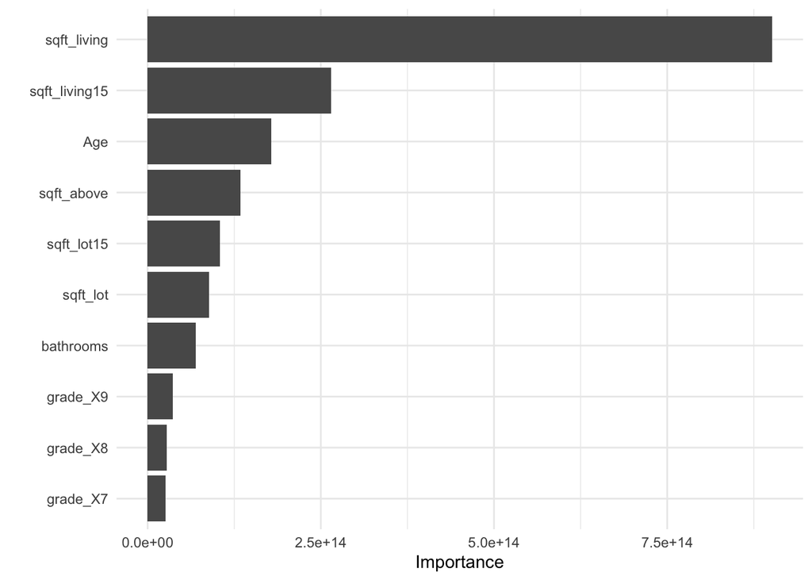

```r
randomforest_final_train <- finalize_workflow(rf_wokflow, bestrandomforest)
randonforest_fit <- fit(randomforest_final_train, data = housing_train)
randonforest_fit %>%
  extract_fit_parsnip() %>%
  vip() + theme_minimal()
```

Before we make the model, we think the square of living is the most importance predictor. After we finish all the steps, the result is not out of my mind. This means that the more square living footage you have, the more money you need to spend on your house. However, the second indicator surprised me, **sqft_living15**. It means that the price also correlates to the nearest 15 houses’ square living footage.

For the next step, I will talk about the realtionship between the predictor value and actual value.

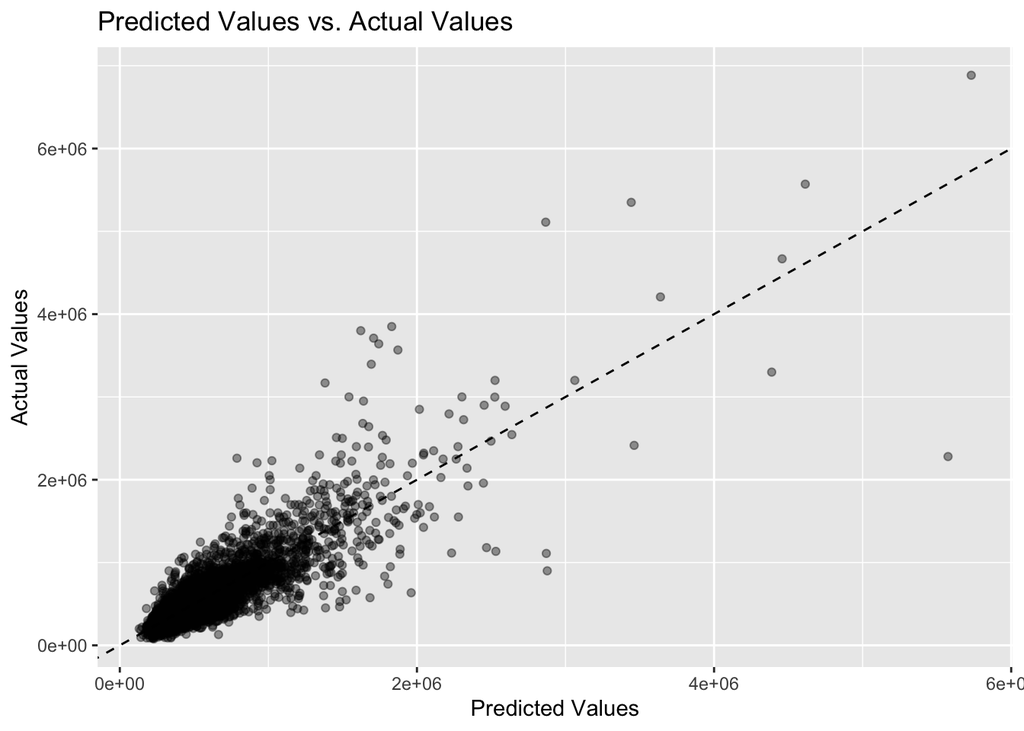

```r
housing_tibble <- predict(randonforest_fit, new_data = housing_test%>%select(-price))
housing_tibble <- bind_cols(housing_tibble, housing_test %>% select(price))


housing_tibble %>%
  ggplot(aes(x = .pred, y = price)) +
  geom_point(alpha = 0.4) +
  geom_abline(lty = 2) +
  theme_grey() +
  labs(title = "Predicted Values vs. Actual Values",
       x = "Predicted Values",
       y = "Actual Values")
```

At last, we need to apply the model to the data testing set

```r
rmse <- sqrt(mean((housing_tibble$.pred - housing_tibble$price)^2))
print(paste("RMSE: ", rmse))
```

```
## [1] "RMSE:  195763.665552689"
```

## Conclusion

Overall, this was my first experience working independently on a machine learning project. From screening the information to removing superfluous components to forming the final model, each step was an opportunity for learning for me. I also recognize that my expertise of machine learning is still quite limited at this point, and it is insufficient to enable me finish many sophisticated models. However, this is an excellent start for me, and this project has increased my interest in the topic of machine learning.